# A Slope Chart Example

dagtann

November 20, 2015

# Introduction

Slope charts gauge change. They compare measurements at two different time points, say a start and an end date, and disregard any other measurement occasion in between. In effect, slope charts create a short hand summary for time series data.

# Demonstration using ggplot2

Let’s create toy data that include an identifier for labeling and grouping, an occasion indicator and - of course - a measurement value.

```r
set.seed(1)                         ## reproducible toy data
dta <- expand.grid(id = rep(letters[1:10]), t = c(1:3))
dta[, 'value'] <- runif(n = nrow(dta))
head(dta)
```

```
##   id t     value
## 1  a 1 0.2655087
## 2  b 1 0.3721239
## 3  c 1 0.5728534
## 4  d 1 0.9082078
## 5  e 1 0.2016819
## 6  f 1 0.8983897
```

The actual chart requires very little work. It is a simple line chart with t on the x and the measurement value on the y-axis. There are just three things to keep in mind. First, judging from my experience it is best to factor t before plotting. This avoids unwanted ticks between the measurement occasions. Second, geom_line() requires an aes(group = id) mapping. Otherwise the line would connect all measurements. Finally, labeling the individual slopes is tricky. Textual labels often overlap as in the plot below. Mapping them to line type, colour or size has limits too. Consequently, slope charts work best if there are few time series to plot.

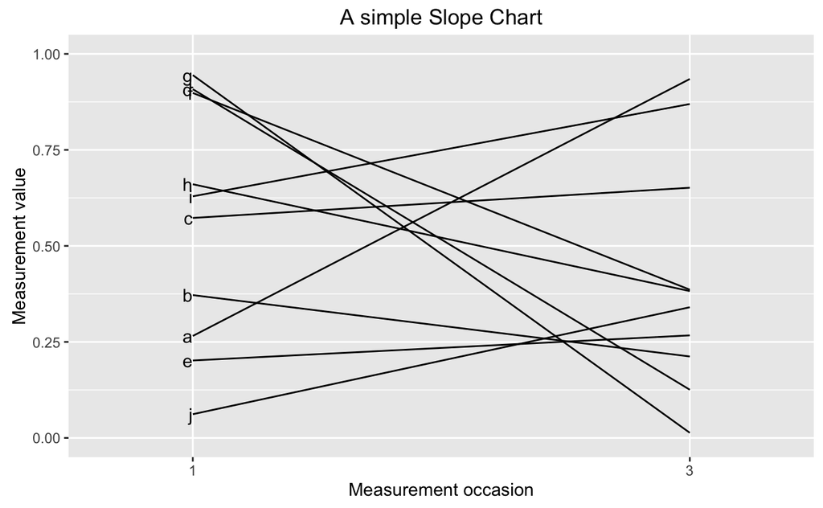

```r
library('ggplot2')
p <- ggplot(
  data = subset(dta, t %in% c(min(t), max(t))),
  # drop measurements between start and end
  aes(x = factor(t), y = value)
) +
  geom_line(aes(group = id)) +
  geom_text(                          # add left-hand labels
    data = subset(dta, t == 1), aes(label = id), hjust = 1
  ) +
  scale_y_continuous(
    limits = c(0, 1), breaks = seq(0, 1, .25)
  ) +
  scale_x_discrete(expand = c(0.25, 0)) +
  # reduce distance data to y-axis
  labs(
    x = 'Measurement occasion', y = 'Measurement value',
    title = 'A simple Slope Chart'
  )
print(p)
```

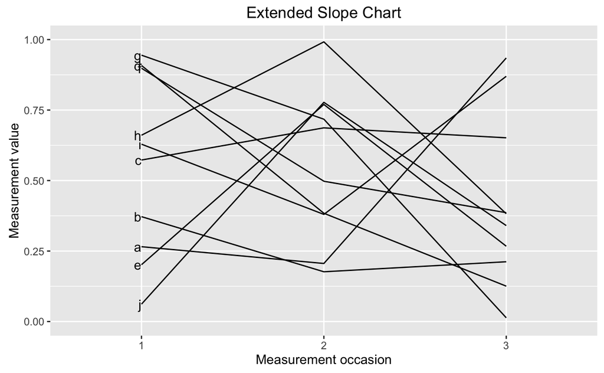

```r
p <- ggplot(
  data = dta,
  # drop measurements between start and end
  aes(x = factor(t), y = value)
) +
  geom_line(aes(group = id)) +
  geom_text(                          # add left-hand labels
    data = subset(dta, t == 1), aes(label = id), hjust = 1
  ) +
  scale_y_continuous(
    limits = c(0, 1), breaks = seq(0, 1, .25)
  ) +
  scale_x_discrete(expand = c(0.25, 0)) +
  # reduce distance data to y-axis
  labs(
    x = 'Measurement occasion', y = 'Measurement value',
    title = 'Extended Slope Chart'
  )
print(p)
```

```r
# Houskeeping ---------------------------------------------
rm(dta, p); detach(package:ggplot2)
# END
```